# Meta-analysis fear learning

Caspar J. Van Lissa, for Elise Heesbeen & Lucianne Groenink

10 February, 2022

```
## v  Loading original data from 'dat.csv'.
```

## 0.1 Descriptive statistics

The effect size estimates ranged from -5.77 to 7.45 ($M = 0.55, SD = 1.57$). One study had an effect size estimate almost 15 standard deviations from the mean effect size ($Z = 14.98$); it was removed as an outlier. Sample sizes ranged from 8 to 75 animals ($M = 21.23, SD = 9.93$).

## 0.2 Meta-analysis

Meta-analysis was conducted in R (R Core Team 2021) using the R-packages `metafor` (Viechtbauer et al. 2010), and `pema` (Van Lissa and Van Erp 2021). To estimate overall effects, we used random-effects meta-analysis (Hedges and Vevea 1998). Separate meta-analyses were conducted for each of the fear learning processes. The overall pooled effect sizes were:

| Parameter | Estimate | p | Process | CI |
| --- | --- | --- | --- | --- |
| Overall ES | -0.0104581539618344 | 0.962257684504006 | Acq learn to cue | [-0.44, 0.42] |
| Tau2 | 1.62854428131133 | 1.70102254748612e-22 | Acq learn to cue | [1.28, 4.44] |
| Overall ES | 0.242504567028083 | 0.229645058753243 | Acq learn to ctx | [-0.15, 0.64] |
| Tau2 | 1.3243728484486 | 1.44817079330544e-25 | Acq learn to ctx | [0.83, 2.59] |
| Overall ES | 0.133182896569567 | 0.380342082439713 | Acq retr to cue | [-0.16, 0.43] |
| Tau2 | 0.706846562298787 | 2.18862604437991e-14 | Acq retr to cue | [0.44, 1.53] |
| Overall ES | 0.837944977990255 | 2.67564501102681e-09 | Acq retr to ctx | [0.56, 1.11] |
| Tau2 | 1.98954382259929 | 5.25784672185727e-87 | Acq retr to ctx | [1.65, 3.16] |
| Overall ES | 0.987404921536115 | 0.00906875066708456 | Ext learn to cue | [0.25, 1.73] |
| Tau2 | 2.15379698961531 | 8.86039667885209e-20 | Ext learn to cue | [1.09, 5.74] |

[output cut: 6 more lines]

The overall effect size estimate differed significantly from zero only for Acq retr to ctx, Ext learn to cue, Ext retr to ctx.

The residual heterogeneity $\tau^2$ was significant for all processes. This indicates that there was substantial heterogeneity between effect sizes across studies.

## 0.3 Forest plots

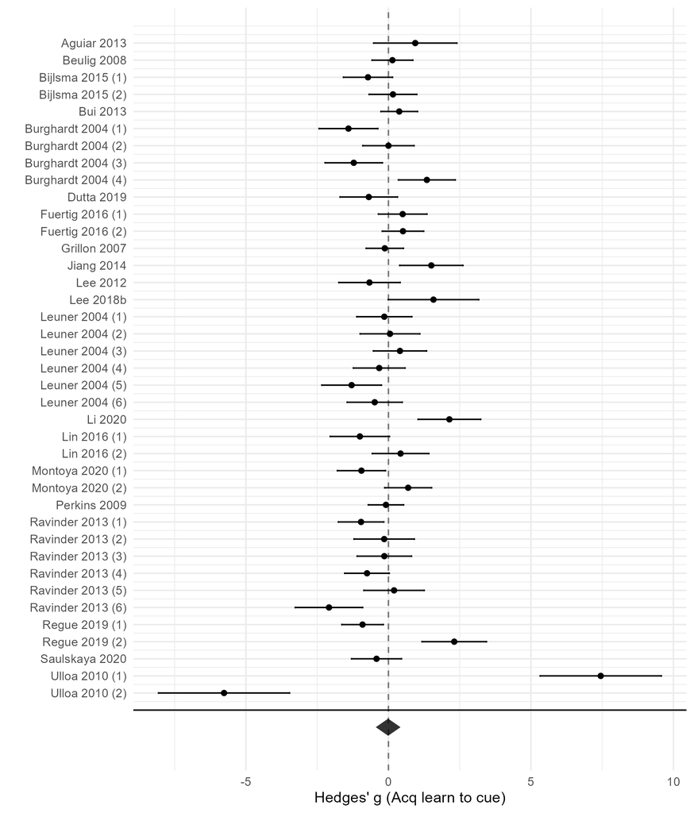

Figure 0.1: Forest plot for Acq learn to cue

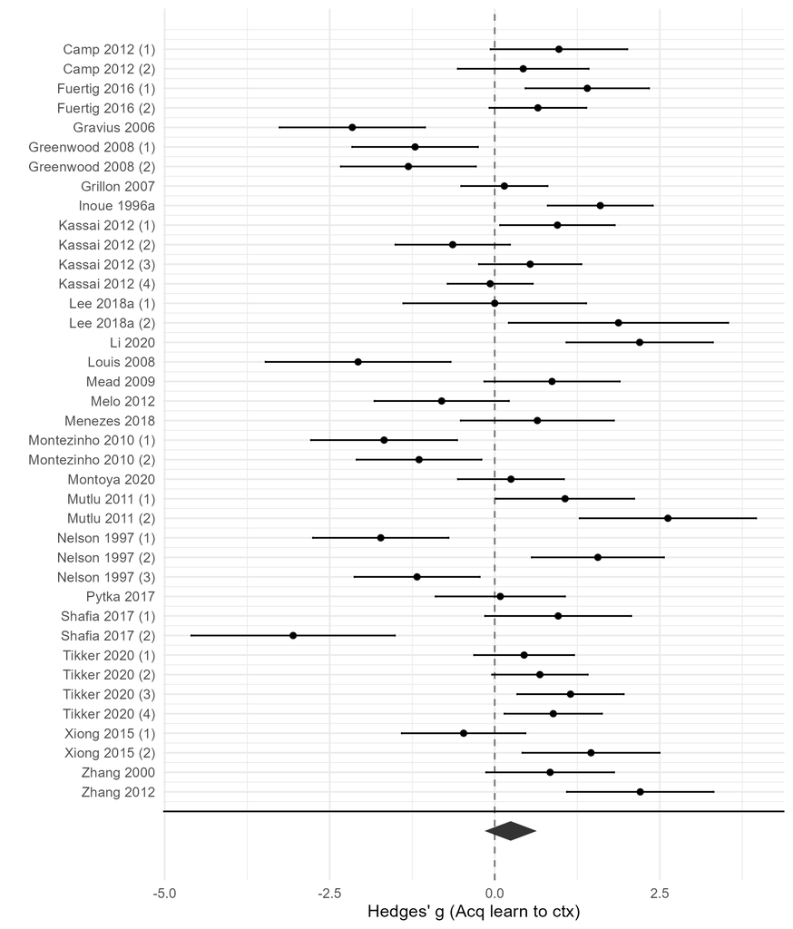

Figure 0.2: Forest plot for Acq learn to ctx

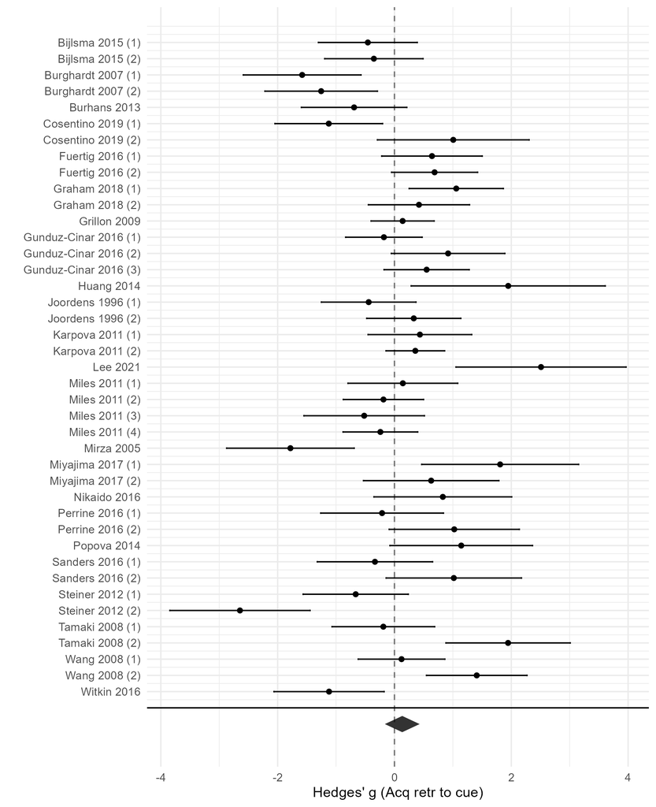

Figure 0.3: Forest plot for Acq retr to cue

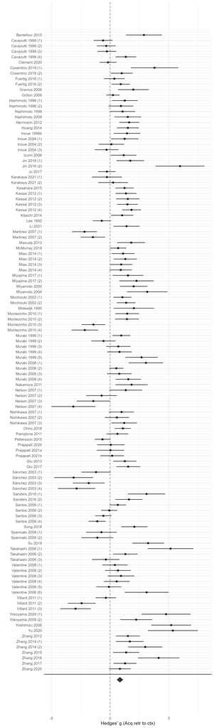

Figure 0.4: Forest plot for Acq retr to ctx

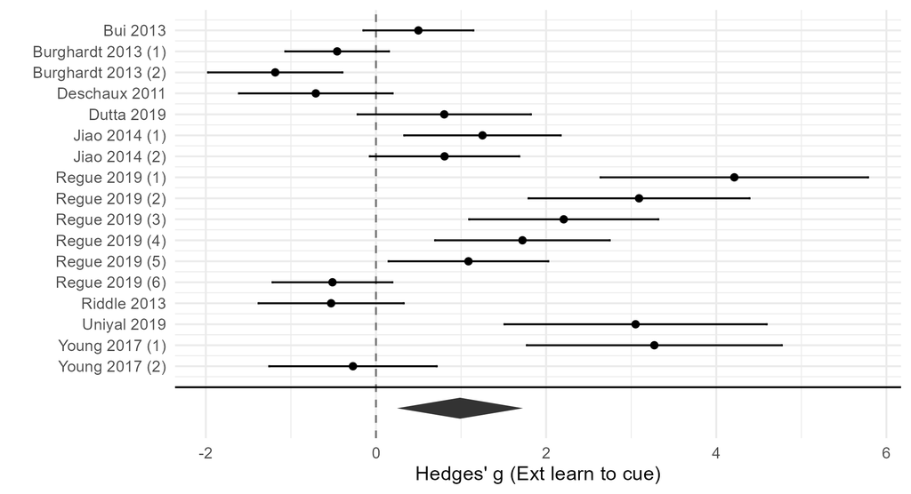

Figure 0.5: Forest plot for Ext learn to cue

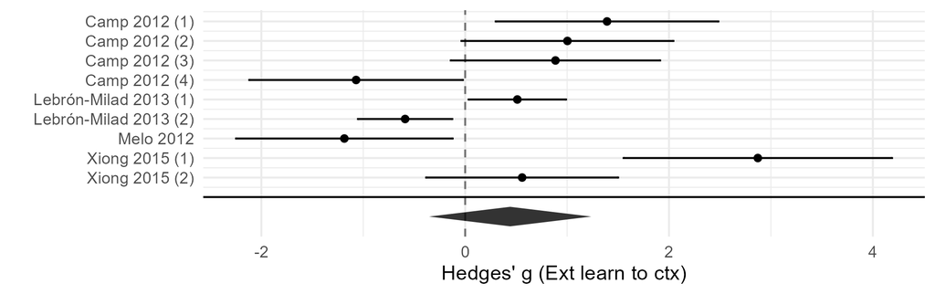

Figure 0.6: Forest plot for Ext learn to ctx

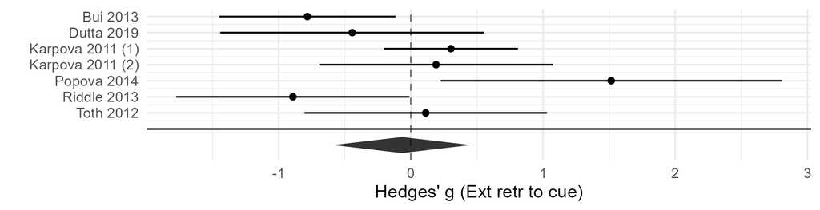

Figure 0.7: Forest plot for Ext retr to cue

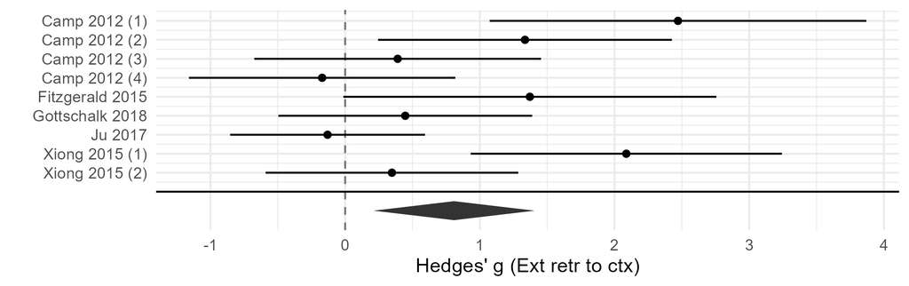

Figure 0.8: Forest plot for Ext retr to ctx

## 0.4 Moderator analyses

Five categorical moderators were coded: (SSRI, frequency, disease induction, species, type of test). The effect of these moderators was investigated using meta-regression. Note however that 33 dummy variables were required to encode all conditions of these categorical moderators. As the number of moderators was approximately equal to the number of available effect sizes (per process), these models were not identified. Addressing this problem requires performing variable selection. Three steps were taken to do so. First, variables and categories that did not occur within one subset of the data were omitted. Secondly, some dummy variables were redundant because some studies had identical values on multiple dummy variables. Only one of these redundant dummy variables was retained, and its name was updated to reflect all redundant dummies it represents. For example, in the “Acq learn to ctx” sample, all human studies used the Fear potentiated startle test; no other studies used this test. Therefore, these two variables were identical and their effects could not be distinguished. Thus, the analysis shows their joint effect as an effect of `specieshuman;testFPS`. Thirdly, despite these measures, many meta-regression models dropped all or some of the predictors, or failed to converge entirely, suggesting the models were empirically non-identified. Although these models are reported below, we advise against their substantive interpretation.

As the models contained only categorical variables but no meaningful reference category, we estimated a model *without* an intercept, and instead included an equal number of dummies to the number of unique categories (ANOVA specification instead of regression specification). This way, the effect of each dummy reflects the mean value for that category. To further aid interpretability, the dependent variable (effect size) was centered around the random-effects meta-analysis estimated overall effect. This changes the interpretation of the effect of each dummy, such that it reflects the deviation of that category from the overall effect size as estimated in the random-effects meta-analysis. If a dummy variable has a significant effect, that means that that group’s mean differs significantly from the overall mean.

### 0.4.1 Classic meta-regression

Note that analyses containing VIF values greater than 5 should be regarded as problematic, due to multicolinearity. This applies to nearly all models.

| Parameter | Estimate | se | p | CI | VIF | format |
| --- | --- | --- | --- | --- | --- | --- |
| ssriESC | -0.223365924329223 | 1.23029755866764 | 0.855932444375864 | [-2.63, 2.19] | 3.4476163074873 | 0 |
| ssriFLX | 0.333702086093425 | 0.796148105869589 | 0.675109624985879 | [-1.23, 1.89] | 4.99556587854997 | 0 |
| ssriPAR | -0.680256785635454 | 1.1102729916993 | 0.540079175866152 | [-2.86, 1.50] | 2.77229738957477 | 0 |
| ssriSER | 1.9239344501276 | 1.3710231624575 | 0.160532258181067 | [-0.76, 4.61] | 1.9585831446074 | 0 |
| freqchronic | 1.03455967180896 | 0.60955836536123 | 0.0896535179903426 | [-0.16, 2.23] | 3.16717412855351 | 0 |
| freqsub | 1.59209380955601 | 1.86446559794818 | 0.393152483471929 | [-2.06, 5.25] | 3.20983079555076 | 0 |
| diseaseind.STRESS | -2.2627912817156 | 2.02548469189239 | 0.263925750457852 | [-6.23, 1.71] | 15.4524265972418 | 0 |
| diseaseind.GMO | 1.07220895652995 | 2.70894450074767 | 0.692250201105954 | [-4.24, 6.38] | 3.14111413053238 | 0 |
| diseaseind.none | -1.21793337156427 | 1.75991729401116 | 0.48891213553419 | [-4.67, 2.23] | 39.9343110326985 | 0 |
| specieshuman | 0.652897519562161 | 2.01279871075288 | 0.745655672264677 | [-3.29, 4.60] | 5.76228064066307 | 0 |

[output cut: 5 more lines]

| Parameter | Estimate | se | p | CI | VIF | format |
| --- | --- | --- | --- | --- | --- | --- |
| ssriESC | -0.830988830743925 | 1.0309101520646 | 0.420200763279093 | [-2.85, 1.19] | 3.46519978987053 | 0 |
| ssriFLX | -1.07399148096826 | 1.03676816095498 | 0.300247293175646 | [-3.11, 0.96] | 14.7993111955064 | 0 |
| ssriPAR | -0.751929004866218 | 1.16554806699465 | 0.518843510967836 | [-3.04, 1.53] | 1.74149630927647 | 0 |
| ssriSER | 0.134117155939964 | 1.13463810770387 | 0.905907142783521 | [-2.09, 2.36] | 2.48251351328546 | 0 |
| freqchronic | 1.38638182832128 | 0.9180002646001 | 0.130987444628889 | [-0.41, 3.19] | 8.89405669656115 | 0 |
| freqsub | 1.39013537418539 | 1.47569178494652 | 0.346180943692186 | [-1.50, 4.28] | 8.44995308593139 | 0 |
| diseaseind.STRESS | -1.07082016223057 | 2.06061231021746 | 0.603299769477026 | [-5.11, 2.97] | 17.4172620658784 | 0 |
| diseaseind.GMO | -1.02435867189322 | 1.99125792066926 | 0.606952842569497 | [-4.93, 2.88] | 5.46304906293489 | 0 |
| diseaseind.none | -1.00579554174744 | 1.74879468337387 | 0.565199027495349 | [-4.43, 2.42] | 57.1865892812182 | 0 |
| diseaseind.OB | -3.20357451624453 | 2.82564669472039 | 0.256899789664399 | [-8.74, 2.33] | 4.37678714044618 | 0 |

[output cut: 9 more lines]

| Parameter | Estimate | se | p | CI | VIF | format |
| --- | --- | --- | --- | --- | --- | --- |
| ssriESC | 1.89888882547288 | 1.22976201905148 | 0.122561490874437 | [-0.51, 4.31] | 6.36151405776594 | 0 |
| ssriFLV | 1.16632554050415 | 0.724041878361901 | 0.10721161295331 | [-0.25, 2.59] | 4.07912528473034 | 0 |
| ssriFLX | 0.925860296353405 | 0.554103960835457 | 0.0947385835497313 | [-0.16, 2.01] | 11.8300096656005 | 0 |
| ssriPAR | 0.774725599572873 | 0.5901833466651 | 0.189288672522582 | [-0.38, 1.93] | 6.0632680488385 | 0 |
| ssriSER | -1.19729733687059 | 1.02998089194541 | 0.245054280753456 | [-3.22, 0.82] | 1.54907125356293 | 0 |
| freqchronic | 0.725597036233264 | 0.312860175652155 | 0.0203821648577143 | [0.11, 1.34] | 4.13671206650256 | 1 |
| freqsub | -0.430843139433694 | 0.846285826750624 | 0.610682939298253 | [-2.09, 1.23] | 4.38513768228182 | 0 |
| diseaseind.STRESS | -0.83472991831283 | 0.839141138831973 | 0.31986119140206 | [-2.48, 0.81] | 8.98890638307477 | 0 |
| diseaseind.highfear | -0.988632922044992 | 1.13144327258237 | 0.382237872303579 | [-3.21, 1.23] | 2.6727471436243 | 0 |
| diseaseind.lowfear | -1.62699628860013 | 1.14288567578907 | 0.154566289822005 | [-3.87, 0.61] | 2.58654553453902 | 0 |

[output cut: 7 more lines]

| Parameter | Estimate | se | p | CI | VIF | format |
| --- | --- | --- | --- | --- | --- | --- |
| ssriESC | -1.35375438347355 | 0.533015664803533 | 0.0110915162541172 | [-2.40, -0.31] | 1.52289359205267 | 1 |
| ssriFLV | 0.71762721591576 | 0.509330490440573 | 0.158846457363033 | [-0.28, 1.72] | 1.54965357362391 | 0 |
| ssriFLX | -0.905302719627762 | 0.508281534441874 | 0.0748953192510245 | [-1.90, 0.09] | 4.53707227425526 | 0 |
| ssriPAR | -0.461378556306996 | 0.632040119237146 | 0.465400562510766 | [-1.70, 0.78] | 2.59173508961018 | 0 |
| ssriSER | -0.678510157267733 | 0.606014998009953 | 0.262873164782108 | [-1.87, 0.51] | 3.83486679503591 | 0 |
| freqchronic | 1.10365283433793 | 0.47992617777402 | 0.02146916756243 | [0.16, 2.04] | 5.17747891940414 | 1 |
| freqsub | 0.215951509795795 | 0.554420677102227 | 0.696900099448358 | [-0.87, 1.30] | 1.82311474595655 | 0 |
| diseaseind.STRESS | -1.93057101394779 | 1.55831164102594 | 0.215387591113052 | [-4.98, 1.12] | 20.768250766669 | 0 |
| diseaseind.GMO | -0.266978730638257 | 1.86137126726067 | 0.885949636831529 | [-3.92, 3.38] | 2.95326883093571 | 0 |
| diseaseind.none | -2.49349735150686 | 1.46554521012856 | 0.0888655029880138 | [-5.37, 0.38] | 109.455695961241 | 0 |

[output cut: 11 more lines]

| Parameter | Estimate | se | p | CI | VIF | format |
| --- | --- | --- | --- | --- | --- | --- |
| ssriESC;specieshuman | 1.32368992321944 | 1.02489495101177 | 0.196517475248934 | [-0.69, 3.33] | 1.45300714820747 | 0 |
| ssriFLX | 0.164409294907172 | 0.862326289910673 | 0.848793646880603 | [-1.53, 1.85] | 1.82505231014096 | 0 |
| ssriPAR | 0.318368609800669 | 0.833815950942416 | 0.702593990172564 | [-1.32, 1.95] | 6.97088976377263 | 0 |
| ssriSER;diseaseind.STRESS | 4.26883612275205 | 1.74585397322037 | 0.0144800812623798 | [0.85, 7.69] | 2.47334629081903 | 1 |
| freqchronic | -1.98108539627545 | 0.720525553819949 | 0.0059686165291157 | [-3.39, -0.57] | 5.09570645383426 | 1 |
| freqsub | -0.671615301917156 | 1.50870911982865 | 0.656204921414386 | [-3.63, 2.29] | 8.09516042103096 | 0 |
| diseaseind.GMO | 2.47161316284161 | 1.62231715511284 | 0.127631660991933 | [-0.71, 5.65] | 7.55508101679024 | 0 |
| diseaseind.none | 0.392070481919947 | 1.41042050292409 | 0.781026737092872 | [-2.37, 3.16] | 31.185774906674 | 0 |
| speciesmouse | 0.0882410658193677 | 0.888224584785516 | 0.920863997695234 | [-1.65, 1.83] | 7.6552134163955 | 0 |
| testCF | -0.223797885406471 | 1.1386430520989 | 0.844181355488601 | [-2.46, 2.01] | 21.9542975989233 | 0 |

[output cut: 1 more lines]

| Parameter | Estimate | se | p | CI | VIF | format |
| --- | --- | --- | --- | --- | --- | --- |
| freqchronic | 1.12161897627371 | 0.995746287106732 | 0.259991845579607 | [-0.83, 3.07] | 9.4524044874993 | 0 |
| diseaseind.STRESS | -0.409657115214919 | 1.99127485430498 | 0.837004906880944 | [-4.31, 3.49] | 3.8492981876306 | 0 |
| diseaseind.none | -2.74860176819224 | 1.36538595880873 | 0.0441084786505593 | [-5.42, -0.07] | 18.9008162052151 | 1 |
| speciesmouse | 0.015985353303871 | 0.757370594566171 | 0.983160793699126 | [-1.47, 1.50] | 2.64727934604375 | 0 |
| testCF | 1.71803302366415 | 1.10891804190901 | 0.121312588003461 | [-0.46, 3.89] | 12.2519888401363 | 0 |
| Tau2 | 0.578847097780638 | 0.582157514207785 | 0.0133135165583741 | [-0.56, 1.72] |  | 1 |

| Parameter | Estimate | se | p | CI | VIF | format |
| --- | --- | --- | --- | --- | --- | --- |
| ssriESC;specieshuman | -0.811127583893008 | 1.27459125428113 | 0.524527136626874 | [-3.31, 1.69] | 2.43753111711763 | 0 |
| ssriFLX | 0.179797352073829 | 0.876992060082391 | 0.837559670771695 | [-1.54, 1.90] | 5.06980609890575 | 0 |
| ssriPAR;freqsub | -0.376671483975789 | 0.899459119708728 | 0.675380178187349 | [-2.14, 1.39] | 1 | 0 |
| freqchronic | 0.095609579998232 | 0.978823701848973 | 0.922187954268001 | [-1.82, 2.01] | 6.50733721602339 | 0 |
| Tau2 | 0.552871893631973 | 0.617083536407021 | 0.0173889279018911 | [-0.66, 1.76] |  | 1 |

| Parameter | Estimate | se | p | CI | VIF | format |
| --- | --- | --- | --- | --- | --- | --- |
| diseaseind.STRESS | 1.27881580146598 | 0.917344177444515 | 0.163305090033366 | [-0.52, 3.08] | 1 | 0 |
| diseaseind.none | -0.412248523444015 | 0.602037996489471 | 0.493498541065157 | [-1.59, 0.77] | 3.69440198665107 | 0 |
| speciesmouse | 0.352394748025199 | 0.704960496490593 | 0.61716047961488 | [-1.03, 1.73] | 3.69440198665107 | 0 |
| Tau2 | 0.498241680344591 | 0.455129144792298 | 0.0119989081178247 | [-0.39, 1.39] |  | 1 |

### 0.4.2 Bayesian regularized meta-regression:

| Parameter | Estimate | se | n_eff | Rhat | CI | p | format |
| --- | --- | --- | --- | --- | --- | --- | --- |
| ssriESC | 0.00657091955368583 | 0.00776804869748378 | 1392.77823719024 | 1.00023975626839 | [-0.71, 0.68] |  | 0 |
| ssriFLX | -0.0330686484748261 | 0.00629919849764163 | 1341.50865025194 | 1.00038974515684 | [-0.59, 0.46] |  | 0 |
| ssriPAR | -0.0396534398285452 | 0.00834627360167239 | 1303.9907984016 | 1.00104738676338 | [-0.83, 0.58] |  | 0 |
| ssriSER | 0.223653493904907 | 0.0120198123040124 | 1481.55551731334 | 0.999589098598854 | [-0.40, 1.49] |  | 0 |
| freqchronic | 0.246092398264933 | 0.0135403301152841 | 637.924858995494 | 1.0021617459912 | [-0.16, 1.09] |  | 0 |
| freqsub | 0.0801350624408837 | 0.00958700450655864 | 1525.90941740191 | 1.00145412531072 | [-0.59, 1.08] |  | 0 |
| diseaseind.STRESS | -0.113714187427389 | 0.0115086224113809 | 807.481136951047 | 1.00280409806524 | [-1.03, 0.38] |  | 0 |
| diseaseind.GMO | 0.14814557237393 | 0.0113185557981923 | 1634.84510432792 | 0.999699039769387 | [-0.57, 1.45] |  | 0 |
| diseaseind.none | -0.0316476886708161 | 0.00836600398343183 | 730.8736578209 | 1.00282673546467 | [-0.61, 0.40] |  | 0 |
| specieshuman | -0.00130457386544243 | 0.00943679879898911 | 931.716307777643 | 1.00279081799168 | [-0.69, 0.63] |  | 0 |

[output cut: 5 more lines]

| Parameter | Estimate | se | n_eff | Rhat | CI | p | format |
| --- | --- | --- | --- | --- | --- | --- | --- |
| ssriESC | -0.101761361452907 | 0.00753580615187858 | 1927.00969715837 | 1.0007573547365 | [-0.95, 0.50] |  | 0 |
| ssriFLX | -0.336839189187867 | 0.0132214404942187 | 825.769681514977 | 1.00875829092486 | [-1.21, 0.17] |  | 0 |
| ssriPAR | 0.0284682949583064 | 0.00691373158236386 | 2852.92441870527 | 1.00030756077932 | [-0.79, 0.89] |  | 0 |
| ssriSER | 0.132614884999841 | 0.00828289486715748 | 2236.67318250375 | 1.00136256367338 | [-0.59, 1.12] |  | 0 |
| freqchronic | 0.335522222224161 | 0.0141694307444978 | 800.809612026666 | 1.0066878992282 | [-0.18, 1.25] |  | 0 |
| freqsub | 0.0870272204154228 | 0.00661467725522813 | 2159.64956087319 | 1.00252860930973 | [-0.47, 0.86] |  | 0 |
| diseaseind.STRESS | 0.139970300235833 | 0.00736423629348316 | 2125.09731665488 | 1.00119951481611 | [-0.43, 1.00] |  | 0 |
| diseaseind.GMO | 0.0341828585358852 | 0.00710293579213072 | 2629.63497636667 | 1.0005262141461 | [-0.73, 0.92] |  | 0 |
| diseaseind.none | 0.0128111090907786 | 0.00549163140657901 | 1874.602744963 | 1.00315155943711 | [-0.50, 0.57] |  | 0 |
| diseaseind.OB | -0.236699180233408 | 0.0106244798853272 | 2520.37344278189 | 0.999861128992131 | [-1.65, 0.59] |  | 0 |

[output cut: 10 more lines]

| Parameter | Estimate | se | n_eff | Rhat | CI | p | format |
| --- | --- | --- | --- | --- | --- | --- | --- |
| ssriESC | 0.211795113881094 | 0.00702981077460318 | 3252.93260734655 | 1.00090545820207 | [-0.44, 1.18] |  | 0 |
| ssriFLV | 0.152108401994779 | 0.00564067901807299 | 2623.1195021187 | 0.999682587823735 | [-0.32, 0.86] |  | 0 |
| ssriFLX | 0.135315181424347 | 0.00498045171807555 | 1976.82511444683 | 0.999489054189741 | [-0.23, 0.68] |  | 0 |
| ssriPAR | 0.00364823266781313 | 0.00386591506664153 | 3267.8467347266 | 1.00054358197009 | [-0.47, 0.49] |  | 0 |
| ssriSER | -0.666373933731095 | 0.0124439035909797 | 2893.15698470167 | 1.00076740410721 | [-2.20, 0.22] |  | 0 |
| freqchronic | 0.536553361176975 | 0.00574010341839849 | 2199.04967657791 | 1.00094660824997 | [0.01, 1.05] | * | 1 |
| freqsub | 0.0589933512838282 | 0.00547753032108147 | 3835.36523259726 | 0.999485187274993 | [-0.66, 0.84] |  | 0 |
| diseaseind.STRESS | 0.194967797954069 | 0.00553596877249436 | 3078.56369143099 | 0.999565518381901 | [-0.30, 0.88] |  | 0 |
| diseaseind.highfear | 0.0681372586787232 | 0.0062741907852652 | 3692.54620681282 | 1.00048116309103 | [-0.67, 0.99] |  | 0 |
| diseaseind.lowfear | -0.0980935138148933 | 0.00625593735938097 | 3626.32022458387 | 1.00049463511638 | [-1.02, 0.61] |  | 0 |

[output cut: 10 more lines]

| Parameter | Estimate | se | n_eff | Rhat | CI | p | format |
| --- | --- | --- | --- | --- | --- | --- | --- |
| ssriESC | -0.69724893411409 | 0.0154309040854793 | 864.456887051062 | 1.00194005024533 | [-1.56, 0.07] |  | 0 |
| ssriFLV | 0.536235218665415 | 0.0139178012149447 | 904.431257921018 | 1.01239648764556 | [-0.12, 1.37] |  | 0 |
| ssriFLX | -0.153447992865291 | 0.00835077208978609 | 1006.53658726432 | 1.00711633312362 | [-0.75, 0.31] |  | 0 |
| ssriPAR | -0.148144253199173 | 0.00888322361087873 | 1476.17296225069 | 1.00181999232073 | [-0.92, 0.47] |  | 0 |
| ssriSER | 0.000454566014128277 | 0.00822320417688278 | 1396.53402648308 | 1.00171051201906 | [-0.68, 0.65] |  | 0 |
| freqchronic | 0.398033397698658 | 0.0119595195374318 | 707.515424116667 | 1.0089378540179 | [-0.10, 1.06] |  | 0 |
| freqsub | -0.0219223866282782 | 0.00781538015208078 | 1530.37540335192 | 1.00203593577147 | [-0.68, 0.62] |  | 0 |
| diseaseind.STRESS | 0.0863700260418769 | 0.0106531717841784 | 1305.48536589416 | 1.00201804761937 | [-0.74, 0.95] |  | 0 |
| diseaseind.GMO | 0.29539255902738 | 0.0109052520434075 | 2643.09866014373 | 1.00146810193672 | [-0.69, 1.61] |  | 0 |
| diseaseind.none | -0.553200727486362 | 0.010653330375735 | 1054.57930477538 | 1.00287548242681 | [-1.25, 0.05] |  | 0 |

[output cut: 12 more lines]

| Parameter | Estimate | se | n_eff | Rhat | CI | p | format |
| --- | --- | --- | --- | --- | --- | --- | --- |
| ssriESC.specieshuman | 0.249786776052105 | 0.0136071330630841 | 2197.29962036065 | 1.00210481652841 | [-0.91, 1.74] |  | 0 |
| ssriFLX | -0.21177446785042 | 0.00929921568516085 | 3260.86359351356 | 1.00022810758284 | [-1.40, 0.78] |  | 0 |
| ssriPAR | 0.318647351196383 | 0.00791905897547625 | 3331.42298447657 | 1.00058705459852 | [-0.48, 1.34] |  | 0 |
| ssriSER.diseaseind.STRESS | 0.78400061291551 | 0.0241640990072026 | 1519.51935121791 | 1.00279616910495 | [-0.56, 3.01] |  | 0 |
| freqchronic | -0.728748727960153 | 0.0164952848498873 | 1317.82659545797 | 1.0036997562104 | [-1.95, 0.24] |  | 0 |
| freqsub | 0.0711243285059775 | 0.0093129311578551 | 3474.82402664625 | 1.00089917725662 | [-1.04, 1.31] |  | 0 |
| diseaseind.GMO | 0.695381770405999 | 0.0169341151679142 | 1907.94289244277 | 1.00268793975394 | [-0.48, 2.31] |  | 0 |
| diseaseind.none | -0.54314131429147 | 0.011711995338058 | 2198.81245382249 | 1.0028276845615 | [-1.74, 0.32] |  | 0 |
| speciesmouse | 0.279921951067502 | 0.00984717088220229 | 2731.11808140388 | 1.00219409371321 | [-0.61, 1.47] |  | 0 |
| speciesrat | -0.0314302568449183 | 0.00850606480778422 | 3071.02615677059 | 1.00023038366067 | [-1.02, 0.95] |  | 0 |

[output cut: 2 more lines]

| Parameter | Estimate | se | n_eff | Rhat | CI | p | format |
| --- | --- | --- | --- | --- | --- | --- | --- |
| freqchronic | 0.243684782134236 | 0.0132472935053667 | 1466.85395952681 | 1.00170618133996 | [-0.60, 1.44] |  | 0 |
| diseaseind.STRESS | 0.461716443336981 | 0.0183062687119257 | 1715.90692054825 | 1.00021116778198 | [-0.73, 2.30] |  | 0 |
| diseaseind.none | -0.428934932148482 | 0.0196376991891678 | 1070.86093020557 | 1.0033215558631 | [-2.04, 0.51] |  | 0 |
| speciesmouse | 0.0273180735380441 | 0.00904411042620071 | 2977.54338755444 | 1.00000622660667 | [-1.04, 1.10] |  | 0 |
| speciesrat | -0.0625984975771332 | 0.0118741180165 | 1530.48576672952 | 1.00167703717686 | [-1.13, 0.91] |  | 0 |
| testCF | 0.206340878565851 | 0.0117726348219668 | 1861.10988597613 | 0.999759058600284 | [-0.66, 1.42] |  | 0 |
| testPMDAT | -0.319266617252396 | 0.0128915094283216 | 2523.79803782804 | 0.999687502236626 | [-1.83, 0.75] |  | 0 |
| tau2 | 1.320331099539 | 0.0349526430405659 | 1290.38572877648 | 1.00211138663441 | [0.09, 4.58] | * | 1 |

| Parameter | Estimate | se | n_eff | Rhat | CI | p | format |
| --- | --- | --- | --- | --- | --- | --- | --- |
| ssriESC.specieshuman | -0.186489212254777 | 0.00931403143001519 | 2312.0259551274 | 1.00188115410666 | [-1.21, 0.58] |  | 0 |
| ssriFLX | 0.107816129461408 | 0.00680121734557013 | 2566.25373208396 | 1.00003466447016 | [-0.52, 0.94] |  | 0 |
| ssriPAR.freqsub | -0.0713650394475762 | 0.00776395106609401 | 2905.05586730318 | 0.99968882676965 | [-1.06, 0.76] |  | 0 |
| freqchronic | -0.0531466612772524 | 0.00653600217963407 | 2701.17019373924 | 0.999399677227226 | [-0.85, 0.58] |  | 0 |
| speciesmouse | 0.0884979197265856 | 0.00656217572913413 | 3013.79708456348 | 0.999749610093587 | [-0.60, 0.97] |  | 0 |
| speciesrat | -0.0267823075265278 | 0.00584815354975362 | 3425.81023138659 | 1.00148399764564 | [-0.80, 0.72] |  | 0 |
| tau2 | 0.551992362243726 | 0.019174269841483 | 1749.18145053383 | 1.00200970505335 | [0.00, 2.52] | * | 1 |

| Parameter | Estimate | se | n_eff | Rhat | CI | p | format |
| --- | --- | --- | --- | --- | --- | --- | --- |
| diseaseind.STRESS | 0.29745222666632 | 0.0110915829499579 | 2516.81407135799 | 1.0006883368899 | [-0.56, 1.70] |  | 0 |
| diseaseind.none | -0.106834683321201 | 0.00792009692289167 | 1820.81730996729 | 1.00013269400822 | [-0.92, 0.54] |  | 0 |
| speciesmouse | 0.0383461888368854 | 0.00888818342502784 | 1655.07761917924 | 1.00001728623257 | [-0.71, 0.88] |  | 0 |
| speciesrat | 0.0244762842446166 | 0.00742972305050581 | 2444.71218288397 | 1.00210062121092 | [-0.77, 0.88] |  | 0 |
| tau2 | 0.758170436658893 | 0.0270360631240473 | 946.35941951144 | 1.00698936307878 | [0.02, 2.76] | * | 1 |

# 1 Conclusion

Hedges, Larry V., and Jack L. Vevea. 1998. “Fixed- and Random-effects Models in Meta-analysis.” *Psychological Methods* 3 (4): 486–504.

R Core Team. 2021. *R: A Language and Environment for Statistical Computing*. Vienna, Austria: R Foundation for Statistical Computing. https://www.R-project.org/.

Van Lissa, C. J., and S. Van Erp. 2021. “Select Relevant Moderators Using Bayesian Regularized Meta-Regression.” *PsyArxiv*. https://doi.org/10.31234/osf.io/6phs5.

Viechtbauer, Wolfgang et al. 2010. “Conducting Meta-Analyses in R with the Metafor Package.” *J Stat Softw* 36 (3): 1–48.